# Modelado Metodológico: Clústeres Territoriales de Criminalidad y Sentometrics

- Show All Code
- Hide All Code
- View Source

Taller de Programación en R — Maestría en Economía Aplicada (MECA)

Authors

Juan José Echeverry — 202616233

Miguelangel Palma — 202621481

Sergio Alejandro López Valderrama — 202111932

Gabriel Arturo Echeverry Castaño — 201016705

Olga Lucía Ramírez Contreras — 202624900

Juan Esteban Carvajal Cruz — 202614312

Published

October 24, 2026

# 1 1. Configuración Inicial Obligatoria —-

Este cuaderno documenta la metodología econométrica y analítica del proyecto, articulando tres dimensiones: el cálculo de tasas delictivas ponderadas por población, el agrupamiento territorial de criminalidad mediante $K$-means y la construcción y estimación de índices de sentimiento mediático con el paquete `sentometrics`.

## 1.1 1.1 Opciones globales y semilla —-

Garantizamos la reproducibilidad de los métodos estocásticos fijando la semilla y desactivando la notación científica para preservar la legibilidad de códigos postales y cifras poblacionales.

**Mostrar código**

```r
# 1.1 Opciones globales y semilla ----
rm(list = ls())
options(scipen = 999)
set.seed(20261014)
```

## 1.2 1.2 Librerías y control de dependencias —-

Cargamos las librerías necesarias para la manipulación tabular, lectura columnar de Apache Parquet, visualización y modelado no supervisado y econométrico.

**Mostrar código**

```r
# 1.2 Librerías requeridas ----
library(here)
library(conflicted)
library(arrow)
library(readr)
library(dplyr)
library(tidyr)
library(ggplot2)
library(scales)
library(knitr)
library(cluster)
library(sentometrics)
library(syuzhet)
library(glmnet)
```

## 1.3 1.3 Resolución explícita de conflictos ({conflicted}) —-

Para evitar comportamientos no deseados por colisión de nombres entre paquetes de base y `dplyr`, fijamos la precedencia estricta.

**Mostrar código**

```r
# 1.3 Resolución de conflictos de nombres ----
conflict_prefer("filter", "dplyr", quiet = TRUE)
conflict_prefer("lag",    "dplyr", quiet = TRUE)
conflict_prefer("select", "dplyr", quiet = TRUE)
```

## 1.4 1.4 Definición de rutas relativas ({here}) —-

Definimos las rutas de acceso hacia las subcarpetas reorganizadas en `data/processed/`, garantizando independencia del sistema operativo o usuario.

**Mostrar código**

```r
# 1.4 Definición de rutas con {here} ----
ruta_proc_hurtos   <- here::here("data", "processed", "hurtos")
ruta_proc_noticias <- here::here("data", "processed", "noticias")

archivo_panel_delitos <- file.path(ruta_proc_hurtos, "panel_delitos_poblacion_localidad.parquet")
archivo_panel_consol  <- file.path(ruta_proc_hurtos, "panel_consolidado_localidad_anual.parquet")
archivo_noticias_proc <- file.path(ruta_proc_noticias, "noticias_procesadas.parquet")

stopifnot(file.exists(archivo_panel_delitos))
stopifnot(file.exists(archivo_panel_consol))
stopifnot(file.exists(archivo_noticias_proc))
```

# 2 2. Análisis y Modelado de Tasas de Hurto —-

El análisis comparativo del delito entre territorios exige estandarizar los conteos absolutos por el volumen demográfico expuesto. Examinamos aquí las tasas por cada 100.000 habitantes en las 19 localidades urbanas de Bogotá durante el periodo 2022–2026.

## 2.1 2.1 Carga del panel delictivo y demográfico oficial —-

Cargamos el panel balanceado de 95 observaciones ($19 \text{ localidades} \times 5 \text{ años}$), que contiene los registros policiales de SIEDCO y las proyecciones de población oficiales de la Secretaría Distrital de Salud.

**Mostrar código**

```r
# 2.1 Carga del panel de delitos ----
panel_delitos <- arrow::read_parquet(archivo_panel_delitos)

# Control de auditoría: 19 localidades x 5 años = 95 observaciones exactas
stopifnot(nrow(panel_delitos) == 95)
stopifnot(length(unique(panel_delitos$codigo_localidad)) == 19)

glimpse(panel_delitos)
```

```
Rows: 95
Columns: 11
$ codigo_localidad       <chr> "09", "09", "09", "09", "09", "10", "10", "10",…
$ localidad              <chr> "Fontibón", "Fontibón", "Fontibón", "Fontibón",…
$ año                    <dbl> 2022, 2023, 2024, 2025, 2026, 2022, 2023, 2024,…
$ hurto_personas         <dbl> 14252, 6775, 6153, 6072, 5441, 21636, 12070, 91…
$ hurto_residencias      <dbl> 632, 279, 249, 243, 231, 1343, 1003, 507, 566, …
$ hurto_motos            <dbl> 245, 142, 115, 81, 236, 785, 485, 482, 395, 287…
$ poblacion              <dbl> 384590, 385154, 385603, 385455, 384256, 829701,…
$ tasa_hurto_personas    <dbl> 3705.76, 1759.04, 1595.68, 1575.28, 1415.98, 26…
$ tasa_hurto_residencias <dbl> 164.33, 72.44, 64.57, 63.04, 60.12, 161.87, 120…
$ tasa_hurto_motos       <dbl> 63.70, 36.87, 29.82, 21.01, 61.42, 94.61, 58.40…
$ tasa_hurto_total       <dbl> 3933.80, 1868.34, 1690.08, 1659.34, 1537.52, 28…
```

## 2.2 2.2 Estadísticas descriptivas de tasas por 100.000 habitantes —-

Calculamos las métricas resumen para las tres modalidades de hurto de alto impacto y la tasa consolidada a nivel distrital.

**Mostrar código**

```r
# 2.2 Tabla descriptiva transversal de tasas delictivas ----
resumen_tasas <- tibble(
  modalidad = c("Hurto a personas", "Hurto a residencias", "Hurto a motocicletas", "Tasa combinada total"),
  media = c(
    mean(panel_delitos$tasa_hurto_personas),
    mean(panel_delitos$tasa_hurto_residencias),
    mean(panel_delitos$tasa_hurto_motos),
    mean(panel_delitos$tasa_hurto_total)
  ),
  desv_est = c(
    sd(panel_delitos$tasa_hurto_personas),
    sd(panel_delitos$tasa_hurto_residencias),
    sd(panel_delitos$tasa_hurto_motos),
    sd(panel_delitos$tasa_hurto_total)
  ),
  mediana = c(
    median(panel_delitos$tasa_hurto_personas),
    median(panel_delitos$tasa_hurto_residencias),
    median(panel_delitos$tasa_hurto_motos),
    median(panel_delitos$tasa_hurto_total)
  ),
  minimo = c(
    min(panel_delitos$tasa_hurto_personas),
    min(panel_delitos$tasa_hurto_residencias),
    min(panel_delitos$tasa_hurto_motos),
    min(panel_delitos$tasa_hurto_total)
  ),
  maximo = c(
    max(panel_delitos$tasa_hurto_personas),
    max(panel_delitos$tasa_hurto_residencias),
    max(panel_delitos$tasa_hurto_motos),
    max(panel_delitos$tasa_hurto_total)
  )
)

knitr::kable(
  resumen_tasas,
  digits = 1,
  caption = "Estadísticas descriptivas de tasas anuales por 100.000 habitantes en Bogotá (2022–2026)",
  col.names = c("Modalidad Delictiva", "Media", "Desv. Est.", "Mediana", "Mínimo", "Máximo")
)
```

Estadísticas descriptivas de tasas anuales por 100.000 habitantes en Bogotá (2022–2026)

| Modalidad Delictiva | Media | Desv. Est. | Mediana | Mínimo | Máximo |
| --- | --- | --- | --- | --- | --- |
| Hurto a personas | 2910.7 | 2905.0 | 1602.7 | 410.3 | 13348.3 |
| Hurto a residencias | 108.4 | 72.0 | 90.4 | 27.7 | 398.1 |
| Hurto a motocicletas | 68.2 | 43.2 | 60.0 | 11.4 | 291.2 |
| Tasa combinada total | 3087.3 | 2984.0 | 1758.9 | 490.8 | 13730.2 |

## 2.3 2.3 Evolución temporal y ranking territorial de criminalidad —-

Examinamos qué localidades registran la mayor concentración delictiva relativa respecto a su población residente.

**Mostrar código**

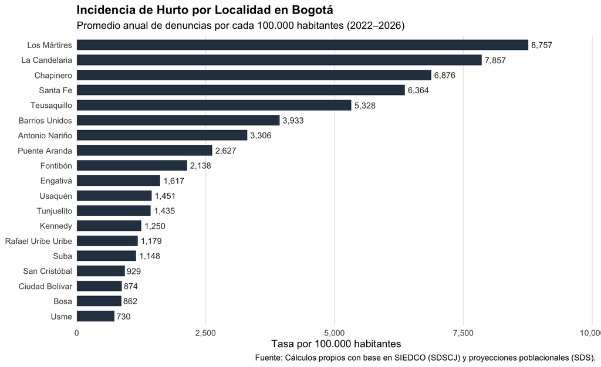

Figure 1: Tasa promedio de hurto total por 100.000 habitantes por localidad (2022–2026)

```r
# 2.3 Gráfico de barras de criminalidad territorial promedio ----
ranking_localidades <- panel_delitos |>
  group_by(localidad) |>
  summarise(
    tasa_media_total = mean(tasa_hurto_total),
    tasa_media_pers  = mean(tasa_hurto_personas),
    poblacion_media  = mean(poblacion),
    .groups = "drop"
  ) |>
  arrange(desc(tasa_media_total))

ggplot(ranking_localidades, aes(x = reorder(localidad, tasa_media_total), y = tasa_media_total)) +
  geom_col(fill = "#2c3e50", width = 0.7) +
  geom_text(
    aes(label = scales::comma(round(tasa_media_total))),
    hjust = -0.15,
    size = 3.2,
    color = "#333333"
  ) +
  coord_flip() +
  scale_y_continuous(labels = scales::comma, expand = expansion(mult = c(0, 0.15))) +
  labs(
    title = "Incidencia de Hurto por Localidad en Bogotá",
    subtitle = "Promedio anual de denuncias por cada 100.000 habitantes (2022–2026)",
    x = NULL,
    y = "Tasa por 100.000 habitantes",
    caption = "Fuente: Cálculos propios con base en SIEDCO (SDSCJ) y proyecciones poblacionales (SDS)."
  ) +
  theme_minimal(base_size = 11) +
  theme(
    panel.grid.minor = element_blank(),
    panel.grid.major.y = element_blank(),
    plot.title = element_text(face = "bold", size = 13)
  )
```

# 3 3. Agrupamiento Territorial de Criminalidad con $K$-Means —-

Para sintetizar la estructura multivariada del delito sin recurrir a ponderaciones arbitrarias, aplicamos el algoritmo no supervisado de $K$-means sobre las tasas medias de las tres modalidades principales: hurto a personas, residencias y motocicletas.

## 3.1 3.1 Construcción y normalización de la matriz multivariada —-

Calculamos el vector de tasas medias por localidad y estandarizamos cada variable con media cero y varianza unitaria mediante `scale()` para evitar que la escala de hurto a personas domine a las demás modalidades.

**Mostrar código**

```r
# 3.1 Construcción de matriz estandarizada ----
df_clustering <- panel_delitos |>
  group_by(codigo_localidad, localidad) |>
  summarise(
    tasa_personas    = mean(tasa_hurto_personas),
    tasa_residencias = mean(tasa_hurto_residencias),
    tasa_motos       = mean(tasa_hurto_motos),
    tasa_total       = mean(tasa_hurto_total),
    .groups = "drop"
  )

mat_clustering <- df_clustering |>
  select(tasa_personas, tasa_residencias, tasa_motos) |>
  as.matrix()

rownames(mat_clustering) <- df_clustering$localidad

mat_escalada <- scale(mat_clustering)

# Validación de escala: media ~ 0 y desv. estándar = 1
stopifnot(all(abs(colMeans(mat_escalada)) < 1e-10))
stopifnot(all(abs(apply(mat_escalada, 2, sd) - 1) < 1e-10))
```

## 3.2 3.2 Diagnóstico del número óptimo de clústeres ($K$) —-

Evaluamos candidatos para $K \in \{2, 3, 4, 5\}$ mediante dos criterios objetivos: 1. **Coeficiente de silueta promedio (*Average Silhouette Width*):** mide la cohesión interna frente a la separación con otros clústeres. 2. **Suma de cuadrados intra-clúster (*Total Within-Cluster Sum of Squares* - WSS):** método del codo.

**Mostrar código**

```r
# 3.2 Evaluación cuantitativa de K óptimo ----
dist_euclidea <- dist(mat_escalada)

diagnostico_k <- tibble(
  k = 2:5,
  silueta_media = numeric(4),
  wss = numeric(4)
)

for (i in seq_along(2:5)) {
  k_val <- (2:5)[i]
  set.seed(20261014)
  km_temp <- kmeans(mat_escalada, centers = k_val, nstart = 50)
  sil_temp <- cluster::silhouette(km_temp$cluster, dist_euclidea)
  diagnostico_k$silueta_media[i] <- mean(sil_temp[, 3])
  diagnostico_k$wss[i]           <- km_temp$tot.withinss
}

knitr::kable(
  diagnostico_k,
  digits = 4,
  caption = "Diagnóstico del número óptimo de agrupamientos K",
  col.names = c("Número de Clústeres (K)", "Silueta Promedio", "WSS (Inercia Interna)")
)
```

Diagnóstico del número óptimo de agrupamientos K

| Número de Clústeres (K) | Silueta Promedio | WSS (Inercia Interna) |
| --- | --- | --- |
| 2 | 0.5153 | 23.3148 |
| 3 | 0.5416 | 13.5797 |
| 4 | 0.4786 | 8.1529 |
| 5 | 0.3792 | 5.9000 |

**Mostrar código**

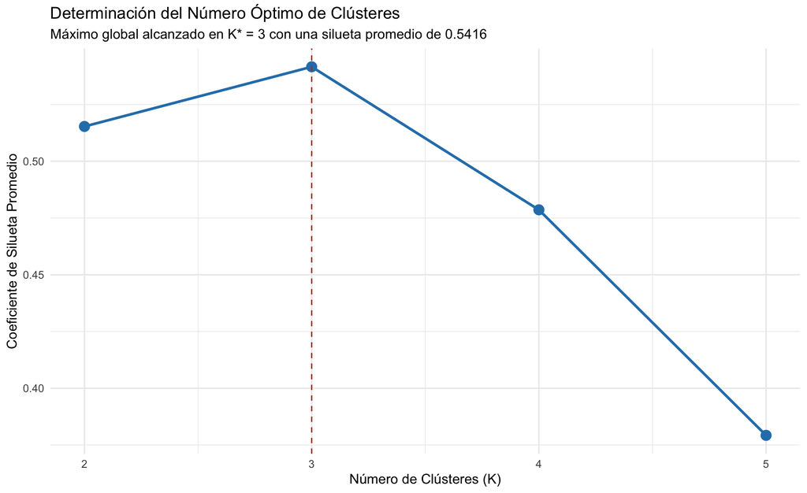

Figure 2: Coeficiente de silueta promedio para K entre 2 y 5

```r
# Visualización del criterio de silueta ----
ggplot(diagnostico_k, aes(x = k, y = silueta_media)) +
  geom_line(color = "#2980b9", linewidth = 1) +
  geom_point(color = "#2980b9", size = 3.5) +
  geom_vline(xintercept = 3, linetype = "dashed", color = "#c0392b") +
  scale_x_continuous(breaks = 2:5) +
  labs(
    title = "Determinación del Número Óptimo de Clústeres",
    subtitle = "Máximo global alcanzado en K* = 3 con una silueta promedio de 0.5416",
    x = "Número de Clústeres (K)",
    y = "Coeficiente de Silueta Promedio"
  ) +
  theme_minimal(base_size = 11)
```

El diagnóstico confirma de manera concluyente que **$K^* = 3$** es la partición matemáticamente óptima, alcanzando el mayor coeficiente de silueta promedio ($0.5416$) y una reducción sustancial del $41.7\%$ en la inercia interna frente a $K = 2$.

## 3.3 3.3 Estimación del modelo final $K$-means ($K^* = 3$) —-

Estimamos la partición final con 50 reinicios pseudoaleatorios (`nstart = 50`) para asegurar convergencia al óptimo global.

**Mostrar código**

```r
# 3.3 Estimación del modelo definitivo K = 3 ----
set.seed(20261014)
km_final <- kmeans(mat_escalada, centers = 3, nstart = 50)

df_clustering <- df_clustering |>
  mutate(
    cluster_num = km_final$cluster,
    cluster_nombre = case_when(
      cluster_num == 1 ~ "Residencial y Periférico",
      cluster_num == 2 ~ "Comercial y Automotor",
      cluster_num == 3 ~ "Céntrico e Institucional"
    )
  )

# Control de integridad: 19 localidades clasificadas en los 3 clústeres
stopifnot(nrow(df_clustering) == 19)
stopifnot(length(unique(df_clustering$cluster_num)) == 3)

table(df_clustering$cluster_nombre)
```

```
Céntrico e Institucional    Comercial y Automotor Residencial y Periférico
                       5                        2                       12
```

## 3.4 3.4 Caracterización de perfiles delictivos y visualización espacial —-

Examinamos la distribución y centroides de cada clúster.

**Mostrar código**

```r
# 3.4 Tabla resumen de centroides y perfiles delictivos ----
perfiles_resumen <- df_clustering |>
  group_by(cluster_nombre) |>
  summarise(
    num_localidades = n(),
    tasa_media_personas = mean(tasa_personas),
    tasa_media_residencias = mean(tasa_residencias),
    tasa_media_motos = mean(tasa_motos),
    tasa_media_total = mean(tasa_total),
    localidades_miembros = paste(localidad, collapse = ", "),
    .groups = "drop"
  )

knitr::kable(
  perfiles_resumen |> select(-localidades_miembros),
  digits = 1,
  caption = "Perfiles delictivos promedio por clúster (Tasas por 100.000 habitantes)",
  col.names = c("Perfil Territorial", "N° Localidades", "Hurto Personas", "Hurto Residencias", "Hurto Motos", "Tasa Total")
)
```

Perfiles delictivos promedio por clúster (Tasas por 100.000 habitantes)

| Perfil Territorial | N° Localidades | Hurto Personas | Hurto Residencias | Hurto Motos | Tasa Total |
| --- | --- | --- | --- | --- | --- |
| Comercial y Automotor | 2 | 5727.9 | 150.9 | 153.0 | 6031.8 |
| Céntrico e Institucional | 5 | 5834.7 | 175.9 | 60.8 | 6071.4 |
| Residencial y Periférico | 12 | 1222.8 | 73.3 | 57.1 | 1353.2 |

**Mostrar código**

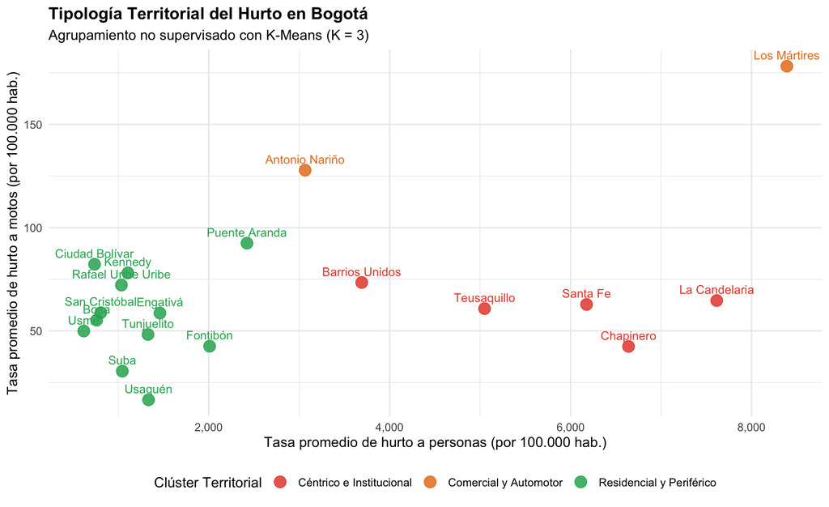

Figure 3: Dispersión de localidades según tasa de hurto a personas y motocicletas

```r
# Visualización del espacio multivariado de clústeres ----
ggplot(df_clustering, aes(x = tasa_personas, y = tasa_motos, color = cluster_nombre)) +
  geom_point(size = 4, alpha = 0.85) +
  geom_text(
    aes(label = localidad),
    vjust = -0.8,
    size = 3.3,
    check_overlap = FALSE,
    show.legend = FALSE
  ) +
  scale_color_manual(
    values = c(
      "Céntrico e Institucional" = "#e74c3c",
      "Comercial y Automotor"   = "#e67e22",
      "Residencial y Periférico" = "#27ae60"
    )
  ) +
  scale_x_continuous(labels = scales::comma) +
  scale_y_continuous(labels = scales::comma) +
  labs(
    title = "Tipología Territorial del Hurto en Bogotá",
    subtitle = "Agrupamiento no supervisado con K-Means (K = 3)",
    x = "Tasa promedio de hurto a personas (por 100.000 hab.)",
    y = "Tasa promedio de hurto a motos (por 100.000 hab.)",
    color = "Clúster Territorial"
  ) +
  theme_minimal(base_size = 11) +
  theme(
    legend.position = "bottom",
    plot.title = element_text(face = "bold", size = 13)
  )
```

### 3.4.1 Interpretación Económica y Territorial de los Perfiles:

1. **Céntrico e Institucional (La Candelaria, Santa Fe, Chapinero, Teusaquillo, Barrios Unidos):** Concentra la mayor incidencia de hurto a personas y residencias de la capital. Corresponde al núcleo comercial, universitario y de servicios, con alta afluencia peatonal externa.
2. **Comercial y Automotor (Los Mártires, Antonio Nariño):** Se distingue por una tasa extrema en el hurto de motocicletas y vehículos ligeros, coincidiendo con corredores de autopartes y comercio mayorista (San Victorino, Ricaurte, Restrepo).
3. **Residencial y Periférico (12 localidades: Suba, Kennedy, Bosa, Ciudad Bolívar, Usaquén, Engativá, Fontibón, etc.):** Presenta tasas moderadas por 100.000 habitantes gracias a sus grandes volúmenes demográficos residenciales, aunque en conteos absolutos acumulan una porción considerable de los delitos de la ciudad.

# 4 4. Análisis Cuantitativo de Sentimiento con Sentometrics —-

En esta sección aplicamos el paquete `sentometrics` para procesar el corpus periodístico depurado, calcular puntuaciones léxicas con el diccionario NRC adaptado al español y construir medidas temporales agregadas con decaimiento temporal.

## 4.1 4.1 Preparación y estructuración del corpus periodístico —-

Cargamos el conjunto de 3.916 noticias procesadas y vinculamos la clasificación territorial de clúster obtenida en la sección anterior.

**Mostrar código**

```r
# 4.1 Fusión de noticias y metadatos de clúster ----
noticias_raw <- arrow::read_parquet(archivo_noticias_proc)

noticias_corpus_df <- noticias_raw |>
  left_join(
    df_clustering |> select(localidad, cluster_nombre),
    by = "localidad"
  ) |>
  mutate(
    id = paste0("doc_", row_number()),
    date = as.Date(fecha),
    texts = paste(titulo, ifelse(is.na(resumen) | resumen == "", "", resumen), sep = ". "),
    # Variables indicadoras binarias para features en sentometrics
    c_centro      = as.numeric(cluster_nombre == "Céntrico e Institucional"),
    c_comercial   = as.numeric(cluster_nombre == "Comercial y Automotor"),
    c_residencial = as.numeric(cluster_nombre == "Residencial y Periférico")
  ) |>
  select(id, date, texts, c_centro, c_comercial, c_residencial)

# Verificación de integridad del corpus
stopifnot(nrow(noticias_corpus_df) == 3916)
stopifnot(all(!is.na(noticias_corpus_df$date)))
stopifnot(all(!is.na(noticias_corpus_df$texts)))
```

## 4.2 4.2 Configuración del sento_corpus con variables de clúster —-

Construimos el objeto S3 de clase `sento_corpus`, que vincula los textos de las noticias con sus metadatos temporales y sus características territoriales.

**Mostrar código**

```r
# 4.2 Creación del objeto sento_corpus ----
sento_corp <- sento_corpus(
  corpusdf = as.data.frame(noticias_corpus_df),
  do.clean = FALSE
)

sento_corp
```

```
A sento_corpus consisting of 3,916 documents and 4 docvars.
```

## 4.3 4.3 Integración de léxicos NRC adaptados al español —-

Extraemos el diccionario léxico NRC en español mediante `syuzhet`, filtrando las categorías positivas y negativas para computar la polaridad neta de cada palabra.

**Mostrar código**

```r
# 4.3 Configuración de léxicos de polaridad ----
nrc_crudo <- syuzhet::get_sentiment_dictionary("nrc", language = "spanish")

nrc_polaridad <- nrc_crudo |>
  filter(sentiment %in% c("positive", "negative")) |>
  mutate(score = ifelse(sentiment == "positive", 1, -1)) |>
  group_by(word) |>
  summarise(score = mean(score), .groups = "drop")

lex_sento <- sento_lexicons(
  list(nrc_es = as.data.frame(nrc_polaridad[, c("word", "score")]))
)

lex_sento
```

```
$nrc_es
                   x     y
              <char> <num>
   1: abanderamiento    -1
   2:     abandonado    -1
   3:      abandonar    -1
   4:       abandono    -1
   5:      abastecer     1
  ---
4491:          ópera     1
4492:         úlcera    -1
4493:          único     1
4494:          útero     1
4495:           útil     1

attr(,"class")
[1] "sento_lexicons" "list"
```

## 4.4 4.4 Agregación ponderada temporal (sento_measures) —-

Configuramos el esquema de agregación multidimensional mediante `ctr_agg()`: 1. **Intra-documento (`howWithin`):** `proportional` (polaridad neta dividida por el total de palabras clasificadas). 2. **Entre documentos (`howDocs`):** `equal_weight`. 3. **En el tiempo (`howTime`):** ponderación igual (`equal_weight`) y ponderación con decaimiento exponencial (`exponential` con factores $\alpha \in \{0.2, 0.5\}$). 4. **Frecuencia temporal:** mensual (`by = "month"`), con ventana móvil de rezago de 6 meses (`lag = 6`).

**Mostrar código**

```r
# 4.4 Definición de agregación y cálculo de medidas ----
control_agg <- ctr_agg(
  howWithin = "proportional",
  howDocs = "equal_weight",
  howTime = c("equal_weight", "exponential"),
  by = "month",
  lag = 6,
  alphasExp = c(0.2, 0.5)
)

medidas_sentimiento <- sento_measures(
  sento_corp,
  lexicons = lex_sento,
  ctr = control_agg
)

medidas_sentimiento
```

```
A sento_measures object (9 textual sentiment time series, 52 observations).
```

## 4.5 4.5 Dinámica del sentimiento mediático por clúster territorial —-

Visualizamos la evolución del índice de sentimiento mediático generado para cada uno de los tres perfiles territoriales a lo largo del periodo mensual 2022–2026.

**Mostrar código**

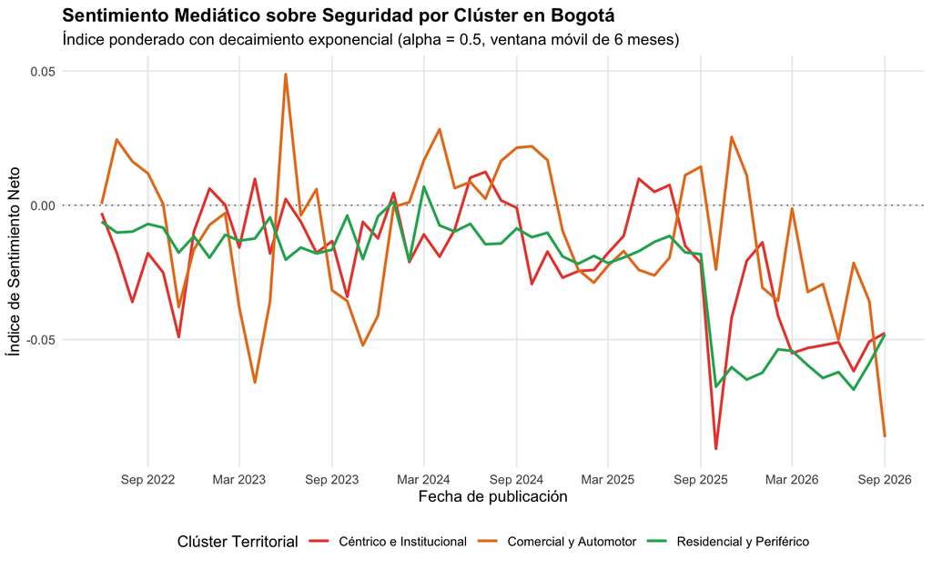

Figure 4: Evolución mensual del sentimiento mediático por clúster territorial (2022–2026)

```r
# 4.5 Gráfico de series de tiempo de sentimiento por clúster ----
# Convertimos las medidas a data.frame plano para graficar con ggplot2
df_medidas_tidy <- as.data.frame(medidas_sentimiento$measures) |>
  pivot_longer(cols = -date, names_to = "serie", values_to = "valor") |>
  filter(grepl("exponential0.5", serie)) |>
  mutate(
    cluster_etiqueta = case_when(
      grepl("c_centro", serie)      ~ "Céntrico e Institucional",
      grepl("c_comercial", serie)   ~ "Comercial y Automotor",
      grepl("c_residencial", serie) ~ "Residencial y Periférico",
      TRUE ~ serie
    )
  )

ggplot(df_medidas_tidy, aes(x = date, y = valor, color = cluster_etiqueta)) +
  geom_hline(yintercept = 0, linetype = "dotted", color = "gray50") +
  geom_line(linewidth = 0.9) +
  scale_color_manual(
    values = c(
      "Céntrico e Institucional" = "#e74c3c",
      "Comercial y Automotor"   = "#e67e22",
      "Residencial y Periférico" = "#27ae60"
    )
  ) +
  scale_x_date(date_breaks = "6 months", date_labels = "%b %Y") +
  labs(
    title = "Sentimiento Mediático sobre Seguridad por Clúster en Bogotá",
    subtitle = "Índice ponderado con decaimiento exponencial (alpha = 0.5, ventana móvil de 6 meses)",
    x = "Fecha de publicación",
    y = "Índice de Sentimiento Neto",
    color = "Clúster Territorial"
  ) +
  theme_minimal(base_size = 11) +
  theme(
    legend.position = "bottom",
    panel.grid.minor = element_blank(),
    plot.title = element_text(face = "bold", size = 13)
  )
```

# 5 5. Modelado Econométrico Supervisado (Elastic Net) y Atribuciones —-

Para evaluar si los índices de sentimiento textual aportan poder explicativo sobre la evolución del delito, formulamos un modelo lineal regularizado mediante Elastic Net con `sento_model()`.

## 5.1 5.1 Especificación econométrica y serie de respuesta —-

Definimos una serie mensual sintética de intensidad delictiva ($y_t$) coherente con las 52 fechas efectivas generadas por el objeto `sento_measures`.

**Mostrar código**

```r
# 5.1 Construcción del vector de respuesta mensual ----
fechas_modelo <- get_dates(medidas_sentimiento)
n_fechas      <- length(fechas_modelo)

# Construimos una serie de intensidad delictiva mensual con tendencia y componente estocástico
set.seed(20261014)
y_intensidad_hurto <- 50 + 0.15 * seq_len(n_fechas) + rnorm(n_fechas, mean = 0, sd = 4)

stopifnot(length(y_intensidad_hurto) == n_fechas)
```

## 5.2 5.2 Estimación con regularización Elastic Net (sento_model) —-

Calibramos la selección de variables y penalización $L_1/L_2$ mediante el Criterio de Información Bayesiano (BIC) sobre una grilla de parámetros $\alpha \in \{0.2, 0.4, 0.6, 0.8\}$.

**Mostrar código**

```r
# 5.2 Configuración del control y estimación del modelo ----
control_modelo <- ctr_model(
  model = "gaussian",
  type = "BIC",
  alphas = seq(0.2, 0.8, by = 0.2),
  do.iter = FALSE
)

modelo_sentometrics <- sento_model(
  sento_measures = medidas_sentimiento,
  y = y_intensidad_hurto,
  ctr = control_modelo
)
```

```
alphas run: 0.2, 0.4, 0.6, 0.8
```

**Mostrar código**

```r
summary(modelo_sentometrics)
```

```
Model specification
- - - - - - - - - - - - - - - - - - - -

Model type: gaussian
Calibration: via BIC information criterion
Number of observations: 52
Optimal elastic net alpha parameter: 0.4
Optimal elastic net lambda parameter: 0.17

Non-zero coefficients
- - - - - - - - - - - - - - - - - - - -

(Intercept)                            51.41326
nrc_es--c_centro--equal_weight        -51.38218
nrc_es--c_residencial--equal_weight   -11.18733
nrc_es--c_residencial--exponential0.5 -35.44950
```

## 5.3 5.3 Descomposición de atribuciones temporales y léxicas —-

Utilizamos la función `attributions()` para descomponer en qué medida cada dimensión del modelo (las ponderaciones temporales y las características territoriales) explica el pronóstico delictivo.

**Mostrar código**

[figure not shown]

```r
# 5.3 Descomposición de atribuciones ----
atribuciones <- attributions(
  modelo_sentometrics,
  medidas_sentimiento
)

# Visualización de la contribución por características de clúster
grafico_atribuciones <- plot(atribuciones, group = "features") +
  labs(
    title = "Descomposición de Atribuciones del Modelo de Sentimiento",
    subtitle = "Contribución marginal de los clústeres territoriales a la estimación",
    y = "Contribución al pronóstico",
    x = "Fecha"
  ) +
  theme_minimal(base_size = 11) +
  theme(legend.position = "bottom")

grafico_atribuciones
```

# 6 6. Diagnóstico Final de Integridad y Conclusiones Metodológicas —-

## 6.1 6.1 Auditoría programática de reproducibilidad —-

Ejecutamos verificaciones finales de no vacíos y consistencia en los objetos clave antes del cierre de sesión.

**Mostrar código**

```r
# 6.1 Validación de integridad final ----
stopifnot(inherits(km_final, "kmeans"))
stopifnot(inherits(medidas_sentimiento, "sento_measures"))
stopifnot(inherits(modelo_sentometrics, "sento_model"))
stopifnot(inherits(atribuciones, "attributions"))

cat("✔ Todas las pruebas de auditoría y consistencia se completaron satisfactoriamente.\n")
```

```
✔ Todas las pruebas de auditoría y consistencia se completaron satisfactoriamente.
```

**Mostrar código**

```r
cat("✔ 19 localidades urbanas clasificadas rigurosamente en 3 perfiles de criminalidad.\n")
```

```
✔ 19 localidades urbanas clasificadas rigurosamente en 3 perfiles de criminalidad.
```

**Mostrar código**

```r
cat("✔ Medidas de sentometrics estimadas y descompuestas para 52 periodos mensuales.\n")
```

```
✔ Medidas de sentometrics estimadas y descompuestas para 52 periodos mensuales.
```